# Medidas de tendencia central

[Edith Constantino Rodríguez](https://edithconstantino.github.io)

Taller IV 2022-2, [Facultad de economía](http://www.economia.unam.mx/)

2/3/2022

### 1. ¿Qué son las medidas de tendencia central? 🤔

> Definición “La medida de tendencia central (moda,media y mediana), parámetro de tendencia central o medida de centralización es un número ubicado hacia el centro de la distribución de los valores de una serie de observaciones (medidas), en la que se encuentra ubicado el conjunto de los datos. Las medidas de tendencia central más utilizadas son: media, mediana u moda. Cuando se hace referencia únicamente a la posición de estos parámetros dentro de la distribución, independientemente de que esté más o menos centrada, se habla de estas medidas como medidas de posición.”

[Wikipedia (2022)](https://es.wikipedia.org/wiki/Medidas_de_tendencia_central)🌟

Para este ejemplo, primero generaremos una serie de **100** números aleatorios entre **1** y **20** mediante la función `sample`. El argumento `TRUE` nos permitirá generar una muestra con remplazo:

```r
numeros <- sample(1:20, 100, TRUE)
numeros
```

```
##   [1]  2  4 11 15  7  3 18 13  2 10  8 16 11 19  6  6 17 13 16 18  8 20  8  6  3
##  [26]  3 12  8 12 12  5  8 17  7  9  8  8 16 12 12 19  3 15 19 19  6  7  6 12 19
##  [51] 16  3  7 20  1  3 19 19 15  8  3 16 11 14  6  7 12  6  4  4  4 16 13  5 18
##  [76]  8  1 20  7 13 17  5 12 20 19  6 12  6 17  2  4  2 18 13 12 14  1  1  3  8
```

### 2. Mediana 📍

> Definición: “En el ámbito de la estadística, la mediana (del latín mediānus ’del medio’1) representa el valor de la variable de posición central en un conjunto de datos ordenados. Se le denota mediana.”

Wikipedia (2022)🌟

Para obtener la **mediana**, podemos ordenar los `numeros` de menor a mayor, **el número que esté en medio de la muestra será la mediana**. Si utilizamos R, se puede hacer el cálculo de la **mediana** con la función `median`:

```r
mediana <- median(numeros)
mediana
```

```
## [1] 9.5
```

### 3. Media 🧮

> Definición: “La media es el valor promedio de un conjunto de datos numéricos, calculada como la suma del conjunto de valores dividida entre el número total de valores.”

$$Media ={\frac {1}{n}}\sum
_{i=1}^{n}a_{i}={\frac {a_{1}+a_{2}+\cdots +a_{n}}{n}}$$

Si usamos R, podemos obtener la media de una muestra si utlilizamos la función **mean**:

```r
media <- mean(numeros)
media
```

```
## [1] 10.25
```

### 4. Moda 📊

> Definición: “La moda estadística de un conjunto de datos, se define como el número que está representado más veces dentro de esos datos, es decir, aquel número que presenta una mayor frecuencia absoluta dentro de la muestra.”

[Estadisticamente (2022)😁](https://estadisticamente.com/moda-estadistica)

Podemos saber cuál es la **frecuencia** (número de veces que aparece un elemento en una muestra) de cada número si dibujamos un **histograma** con la función `hist`, **aquel elemento con mayor frecuencia será la moda**:

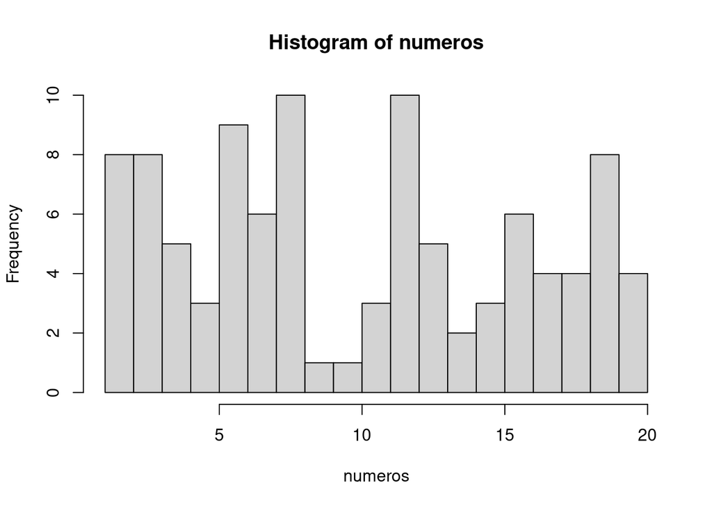

```r
# El argumento breaks nos permite dividir en histograma en las partes que queramos
hist(numeros, breaks = 20)
```

Para obtener un resultado con más precisión, podemos obtener la **moda** si generamos una **tabla de frecuencias** con la función `table` y la función `data.frame`, **aquel elemento con mayor frecuencia será la moda**:

```r
tabla.frecuencias <- data.frame(table(numeros))
tabla.frecuencias
```

```
##    numeros Freq
## 1        1    4
## 2        2    4
## 3        3    8
## 4        4    5
## 5        5    3
## 6        6    9
## 7        7    6
## 8        8   10
## 9        9    1
## 10      10    1
## 11      11    3
## 12      12   10
## 13      13    5
## 14      14    2
## 15      15    3
## 16      16    6
## 17      17    4
## 18      18    4
## 19      19    8
## 20      20    4
```

### 5. Ejercicio 👩‍💻👨‍💻✍

Aplica lo que aprendiste, obten la **mediana**, **media** y **moda** de la siguiente muestra de números:

```r
# Con la función seq, creamos una secuencia de 1 a 10 en intervalos de 0.1 en 0.1
secuencia <- seq(1, 10, 0.1)
muestra <- sample(secuencia, 100, TRUE)
muestra
```

```
##   [1]  6.1  3.7 10.0  4.3  8.4  6.4  8.5  5.5  4.7  8.9  9.4  5.5  8.0  5.0  7.9
##  [16]  3.9  7.5  6.6  3.4  7.8  3.3  6.0  3.8  1.6  8.8  6.4  8.0  9.5  3.9  6.6
##  [31]  7.7  3.1  1.8  1.3  5.4 10.0  6.2  7.1  3.4  4.9  6.8  6.5  9.0  7.7  1.1
##  [46]  6.8  1.9  5.9  5.2  9.6  3.3  7.5  3.7  6.4  3.3  4.9  3.1  4.7  9.7  1.5
##  [61]  5.4  9.0  2.8  3.9  4.0  2.0  7.1 10.0  7.0  5.7  1.5  7.2  9.9  7.1  1.6
##  [76]  8.4  5.2  3.9  6.0  5.0  6.0  6.9  5.7  5.6  9.4 10.0  4.4  2.1  9.5  2.2
##  [91]  7.3  2.0  2.4  5.1  1.0  4.3  7.8  4.8  3.6  5.7
```

##### Mediana

```r
# Aquí el cálculo de la mediana
mediana.muestra <-median(muestra)
mediana.muestra
```

```
## [1] 5.7
```

##### Media

```r
# Aquí el cálculo de la media
media.muestra <- mean(muestra)
media.muestra
```

```
## [1] 5.674
```

##### Moda

```r
# Aquí el cálculo de la moda
moda.muestra <- data.frame(table(muestra))
moda.muestra
```

```
##    muestra Freq
## 1        1    1
## 2      1.1    1
## 3      1.3    1
## 4      1.5    2
## 5      1.6    2
## 6      1.8    1
## 7      1.9    1
## 8        2    2
## 9      2.1    1
## 10     2.2    1
## 11     2.4    1
## 12     2.8    1
## 13     3.1    2
## 14     3.3    3
```

[output cut: 47 more lines]

💻[Código disponible en RStudio Cloud](https://rstudio.cloud/project/3671022)💻